# Vizualizing Arrest Data from Philadelphia, PA

# Drug Posession Arrests Overtime

Using the seaborn package, this vizualization displays Drug Posession Arrests from 2011 to 2023. In 2014, the city of Philadelphia decriminalized marijuana possession, and in 2020 at the beginning of the pandemic, the police department delayed arrests for all narcotic activity. This vizualization portays how drug arrests changed overtime as these changes in policy went into effect. We chose this specific seaborn plot because it is easier for the audience to understand how each year compares to trends from previous years.

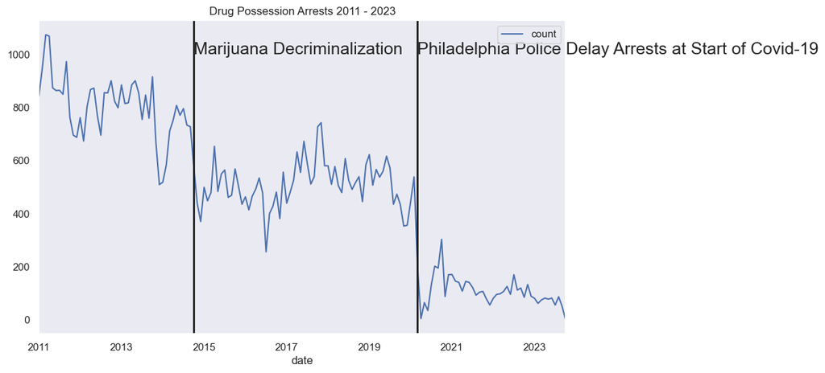

```python
fig, ax = plt.subplots(figsize=(10,6))
drugposses.plot(x='date', y = 'count', ax = ax)
ax.axvline(x='2020-03-17', color='k', linewidth=2)
ax.text('2020-03-17', 1000, "Philadelphia Police Delay Arrests at Start of Covid-19", ha='left', fontsize=18);
ax.axvline(x='2014-10-20', color='k', linewidth=2)
ax.text('2014-10-20', 1000, "Marijuana Decriminalization", ha='left', fontsize=18);
ax.set_title("Drug Possession Arrests 2011 - 2023")
```

# Looking at the Changes in Drug Posession Arrests Following Marijuana Decriminalization and Arrest Deklay

This plot displays Drug Posession from 2011 to 2023, with vertical lines displaying when marijuana was decriminalized and when Philaelphia police delayed arrests at the start of the pandemic. This plot allows the audience to see visually when these changes took plays, and look more specifically into the possible correlation between marijuana decriminalization and drug possession arrests.

```python
mask = (offensesum['date'] >= '2018-01-01') & (offensesum['date'] <= '2023-12-31')
offensesum1823 = offensesum[mask]
offensesum1823.head()
```

|  | offense_category | date | count | objectid | year | month | percent_change |
| --- | --- | --- | --- | --- | --- | --- | --- |
| 84 | Aggravated Assault | 2018-01-01 | 265 | 20773355 | 2018 | 1 | 9.958506 |
| 85 | Aggravated Assault | 2018-02-01 | 205 | 20773430 | 2018 | 2 | -22.641509 |
| 86 | Aggravated Assault | 2018-03-01 | 233 | 20773494 | 2018 | 3 | 13.658537 |
| 87 | Aggravated Assault | 2018-04-01 | 247 | 20773568 | 2018 | 4 | 6.008584 |
| 88 | Aggravated Assault | 2018-05-01 | 296 | 20773634 | 2018 | 5 | 19.838057 |

```python
source = offensesum1823
alt.Chart(offensesum1823).mark_area().encode(
    alt.X('date:T', axis=alt.Axis(format='%Y', domain=False, tickSize=0)),
    alt.Y('count:Q', stack='center', axis=None),
    alt.Color('offense_category:N', scale=alt.Scale(scheme='category20b'), legend=alt.Legend(title='Category of Offense')),
    tooltip=['date:T', 'count:Q', 'offense_category:N']  # Add tooltip encoding
).interactive().properties(
    title='Arrests by Category of Offense'
)
```

[interactive chart not shown]

The above data vizualization displays total arrests by category of offenses as a function of time between 2018 and 2023. In the beginning of 2020, you are able to see a pinch in total arrests across all offenses, and generally a lower total number of arrests after the pandemic.

```python
start_date = '2013-01-01'
end_date = '2016-01-01'

drugpossesfiltered = drugposses[(drugposses['date'] >= start_date) & (drugposses['date'] <= end_date)]
```

```python
source = drugpossesfiltered
brush = alt.selection_interval()
alt.Chart(source).mark_bar().encode(
    x=alt.X('date:T', title='Date'),
    y=alt.Y('percent_change:Q', title='Percent Change'),
    color=alt.condition(
        alt.datum.percent_change > 0,
        alt.value("steelblue"),
        alt.value("orange")
    )
).add_selection(brush).properties(
    width=600,
    title='Percent Change in Drug Possession Over Time'
)
```

[interactive chart not shown]

The above graph shows the percent change in arrests for drug possession between 2013 and 2016.

```python
filtered_1823 = offensesum1823[offensesum1823['offense_category'].isin(['Burglary/Commercial', 'Burglary/Residential'])]

source = filtered_1823

chart = alt.Chart(source).mark_line().encode(
    alt.X('date:T', title='Date'),
    alt.Y('sum(count):Q', title='Sum of Arrests'),
    color=alt.Color(('offense_category'), title='Type of Offense'),
)

chart = chart + chart.transform_filter(alt.datum.offense_category == "Commercial Burglary").properties(
    width=600,
    title='Arrests for Commercial Burglary (2013-2016)'
) + chart.transform_filter(alt.datum.offense_category == "Residential Burglary").properties(
    width=600,
    title='Arrests for Residential Burglary (2013-2016)'
)

chart.display()
```

[interactive chart not shown]

# Summary

The final vizualization shows the change in Commercial Burglary and Residential Burglary between 2018 and 2023. The spike in commercial burglaries in 2020 could possibly be attributed to the Black Lives Matter protests in June of 2020. Additionally, you are able to see a spike in commercial burglaries. This could be attributed to recent lootings in Philadelphia in response to recent ocurt rulings regarding police brutality in the city of Philadelphia/ Overall, from these vizualizations, we are able to see how the greater political and social context within a municipality impacts total arrests for specific types of crime.